# Travel Package Purchase Prediction

# Model performance improvement - Boosting

- Customer purchased package and model predicted customer will purchase travel package : True Positive (observed=1,predicted=1)
- Customer did not purchase package and model predicted customer will purchase travel package : False Postive (observed=0,predicted=1)
- Customer didnot purchase package and model predicted customer will not purchase travel package : True Negative (observed=0,predicted=0)
- Customer purchased package and model predicted customer will not purchase travel package : False Negative (observed=1,predicted=0)

Since from the above models we had already decided to take Precision and the Travel Company wpould prefer if Precision is maximised which means that the higher Precision is it gives greater chsnces of minimising the false positives in the model. This will aid the comapny in centering more attention to the customers who stand a higher chance of purchasing the travel package and will reduce the company's cost of maketing.

Now we are going to hypertune the models to check if we can improve it further.

## Hyperparameter Tuning

### AdaBoost Classifier

```python
#this is to choose the type of classifier.
abc_tuned = AdaBoostClassifier(random_state=1)

#provide grid of parameters to choose from
## add from article
parameters = {
    #now we will try different max_depth for base_estimator
    "base_estimator":[DecisionTreeClassifier(max_depth=1),DecisionTreeClassifier(max_depth=2),DecisionTreeClassifier(max_depth=3)],
    "n_estimators": np.arange(10,110,10),
    "learning_rate":np.arange(0.1,1,0.1)
}

# Run the grid search
grid_obj = GridSearchCV(abc_tuned, parameters,cv=5)
grid_obj = grid_obj.fit(X_train, y_train)

# Set the clf to the best combination of parameters
abc_tuned = grid_obj.best_estimator_

# Fit the best algorithm to the data.
abc_tuned.fit(X_train, y_train)
```

```
AdaBoostClassifier(base_estimator=DecisionTreeClassifier(max_depth=3),
                   learning_rate=0.2, random_state=1)
```

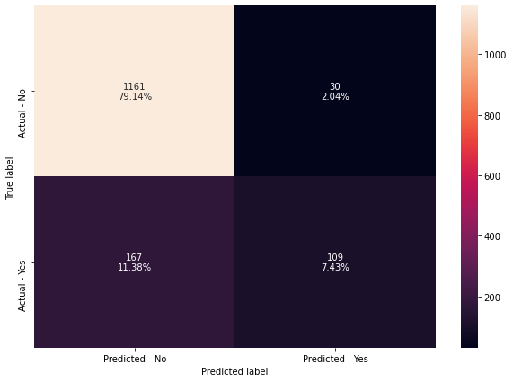

```python
make_confusion_matrix(abc_tuned,y_test)
```

```python
#now we will be using above defined function to get accuracy,precision,recall on train and test set
tuned_abc_acc = get_accuracy_score(abc_tuned)
tuned_abc_precision = get_precision_score(abc_tuned)
tuned_abc_recall = get_recall_score(abc_tuned)
```

```
Accuracy on training set :  0.8868751826951183
Accuracy on test set :  0.8657123381049762
Precision on training set :  0.9003115264797508
Precision on test set :  0.7841726618705036
Recall on training set :  0.44875776397515527
Recall on test set :  0.39492753623188404
```

There is a bit of overfitting after tunning but its not that bad

### Gradient Boosting Classifier

#### Using AdaBoost classifier as the estimator for intial predictions

```python
gbc_init = GradientBoostingClassifier(init=AdaBoostClassifier(random_state=1),random_state=1)
gbc_init.fit(X_train,y_train)
```

```
GradientBoostingClassifier(init=AdaBoostClassifier(random_state=1),
                           random_state=1)
```

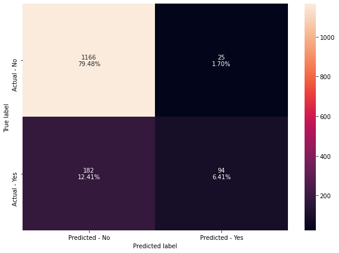

```python
make_confusion_matrix(gbc_init,y_test)
```

```python
#now we would be using above defined function to get accuracy,precision,recall on train and test set
gbc_acc_init = get_accuracy_score(gbc_init)
gbc_acc_precision = get_precision_score(gbc_init)
gbc_acc_recall = get_recall_score(gbc_init)
```

```
Accuracy on training set :  0.8778135048231511
Accuracy on test set :  0.8588957055214724
Precision on training set :  0.8766666666666667
Precision on test set :  0.7899159663865546
Recall on training set :  0.4083850931677019
Recall on test set :  0.34057971014492755
```

Gradient Boosting with Adaboost as base estimator is giving good predictions and there is slight overfitting

### Gradient Boosting Classifier

```python
# Choosing the type of classifier.
gbc_tuned = GradientBoostingClassifier(init=AdaBoostClassifier(random_state=1),random_state=1)

# Grid of parameters to choose from
## add from article
parameters = {
    "n_estimators": [100,150,200,250],
    "subsample":[0.8,0.9,1],
    "max_features":[0.7,0.8,0.9,1]
}

# Type of scoring used to compare parameter combinations


# Run the grid search
grid_obj = GridSearchCV(gbc_tuned, parameters,cv=5)
grid_obj = grid_obj.fit(X_train, y_train)

# Set the clf to the best combination of parameters
gbc_tuned = grid_obj.best_estimator_

# Fit the best algorithm to the data.
gbc_tuned.fit(X_train, y_train)
```

```
GradientBoostingClassifier(init=AdaBoostClassifier(random_state=1),
                           max_features=0.9, n_estimators=250, random_state=1,
                           subsample=1)
```

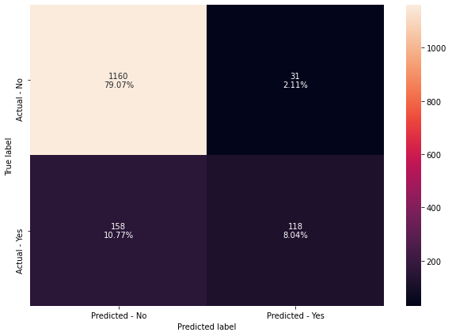

```python
make_confusion_matrix(gbc_tuned,y_test)
```

```python
#now we are going to use above defined function to get accuracy on train and test set
tuned_gbc_acc = get_accuracy_score(gbc_tuned)
tuned_gbc_precision = get_precision_score(gbc_tuned)
tuned_gbc_recall = get_recall_score(gbc_tuned)
```

```
Accuracy on training set :  0.904121601870798
Accuracy on test set :  0.8711656441717791
Precision on training set :  0.9157894736842105
Precision on test set :  0.7919463087248322
Recall on training set :  0.5403726708074534
Recall on test set :  0.427536231884058
```

After Tuning it shows that the model has improved.

### XGBoost Classifier

```python
#this will choose the type of classifier.
xgb_tuned = XGBClassifier(random_state=1,eval_metric='logloss')

# Grid of parameters to choose from
## add from
parameters = {
    "n_estimators": np.arange(30,100,20),
    "subsample":[0.5,0.7,1],
    "learning_rate":[0.001,0.01,0.05,0.1],
    "colsample_bytree":[0.5,0.7,1],
    "colsample_bylevel":[0.5,0.7,1]
}

# Type of scoring used to compare parameter combinations

# Run the grid search
grid_obj = GridSearchCV(xgb_tuned, parameters,cv=5)
grid_obj = grid_obj.fit(X_train, y_train)
```

```python
# Set the clf to the best combination of parameters
xgb_tuned = grid_obj.best_estimator_

# Fit the best algorithm to the data.
xgb_tuned.fit(X_train, y_train)
```

```
XGBClassifier(base_score=0.5, booster='gbtree', colsample_bylevel=0.5,
              colsample_bynode=1, colsample_bytree=0.5, eval_metric='logloss',
              gamma=0, gpu_id=-1, importance_type='gain',
              interaction_constraints='', learning_rate=0.1, max_delta_step=0,
              max_depth=6, min_child_weight=1, missing=nan,
              monotone_constraints='()', n_estimators=90, n_jobs=0,
              num_parallel_tree=1, random_state=1, reg_alpha=0, reg_lambda=1,
              scale_pos_weight=1, subsample=1, tree_method='exact',
              validate_parameters=1, verbosity=None)
```

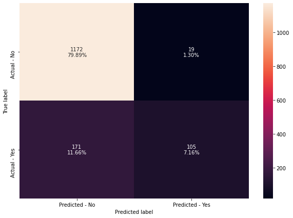

```python
make_confusion_matrix(xgb_tuned,y_test)
```

```python
#Using above defined function to get accuracy,precision and recall on train and test set
tuned_xgb_acc = get_accuracy_score(xgb_tuned)
tuned_xgb_precision = get_precision_score(xgb_tuned)
tuned_xgb_recall = get_recall_score(xgb_tuned)
```

```
Accuracy on training set :  0.9193218357205496
Accuracy on test set :  0.8704839809134287
Precision on training set :  0.9646464646464646
Precision on test set :  0.8467741935483871
Recall on training set :  0.593167701863354
Recall on test set :  0.3804347826086957
```

Both in the initial XGBoost model and the hypertuned model there still overfitting involved in the model.

## Stacking Classifier

```python
estimators=[('Decision Tree', dtree_estimator),('Random Forest', rf_estimator),
           ('Gradient Boosting', gbc_tuned)]
final_estimator=XGBClassifier(random_state=1)
```

```python
stacking_estimator=StackingClassifier(estimators=estimators, final_estimator=final_estimator,cv=5)
stacking_estimator.fit(X_train,y_train)
```

```
StackingClassifier(cv=5,
                   estimators=[('Decision Tree',
                                DecisionTreeClassifier(class_weight={0: 0.19,
                                                                     1: 0.81},
                                                       max_depth=3,
                                                       max_leaf_nodes=10,
                                                       min_impurity_decrease=0.0001,
                                                       random_state=1)),
                               ('Random Forest',
                                RandomForestClassifier(max_features='log2',
                                                       max_samples=0.9,
                                                       n_estimators=501,
                                                       random_state=1)),
                               ('Gradient Boosting',
                                GradientBoostingClassifier(init=AdaBoostC...
                                                 importance_type='gain',
                                                 interaction_constraints=None,
                                                 learning_rate=None,
                                                 max_delta_step=None,
                                                 max_depth=None,
                                                 min_child_weight=None,
                                                 missing=nan,
                                                 monotone_constraints=None,
                                                 n_estimators=100, n_jobs=None,
                                                 num_parallel_tree=None,
                                                 random_state=1, reg_alpha=None,
                                                 reg_lambda=None,
                                                 scale_pos_weight=None,
                                                 subsample=None,
                                                 tree_method=None,
                                                 validate_parameters=None,
                                                 verbosity=None))
```

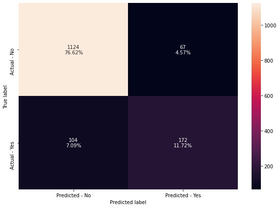

```python
make_confusion_matrix(stacking_estimator,y_test)
```

```python
stacked_acc = get_accuracy_score(stacking_estimator)
stacked_precision = get_precision_score(stacking_estimator)
stacked_recall = get_recall_score(stacking_estimator)
```

```
Accuracy on training set :  0.997953814674072
Accuracy on test set :  0.8834355828220859
Precision on training set :  0.9907550077041603
Precision on test set :  0.7196652719665272
Recall on training set :  0.9984472049689441
Recall on test set :  0.6231884057971014
```

Even with the use of Stacking Classifier it still reveals that there is still overfitting of the data.

since we are done with model performance improvement now we will evaluate and compare which model performance matrics is the best

## Model performance evaluation

### Comparing the models

```python
#this is to define the list of models which were used earlier
models = [dtree,dtree_estimator,bagging,bagging_wt,bagging_estimator,rf,rf_wt,rf_estimator,abc,gbc,xgb,abc_tuned,gbc_init,gbc_tuned,xgb_tuned,stacking_estimator]
#this will help in defining empty lists to add train and test results
acc_train = []
acc_test = []
pres_train =[]
pres_test =[]
recall_train =[]
recall_test =[]

# looping through all the models to get the accuracy,recall and precision scores
for model in models:
    # accuracy score
    j = get_accuracy_score(model,False)
    acc_train.append(j[0])
    acc_test.append(j[1])
    k = get_precision_score(model,False)
    pres_train.append(k[0])
    pres_test.append(k[1])
    l = get_recall_score(model,False)
    recall_train.append(l[0])
    recall_test.append(l[1])
```

```python
#this will create a table for comparisions of the models used for easier insight and better evaluation
comparison_frame = pd.DataFrame({'Model':['Decision Tree','Tuned Decision Tree','Bagging Classifier','Bagging Classifier with weighted decision tree',
                                          'Tuned Bagging Classifier',
                                          'Random Forest','Random Forest with class weights','Tuned Random Forest','Adaboost Classifier',
                                          'Gradient Boosting Classifier','XGBoost classifier',
                                          'Tuned Adaboost Classifier','Gradient Boosting Classifier with Adaboost'
                                          ,'Tuned Gradient Boosting Classifier',
                                          'Tuned XGBoost Classifier','Stacking Classifier'],
                                          'Train_Accuracy': acc_train,
                                          'Test_Accuracy': acc_test,
                                          'Train_Precision':pres_train,
                                          'Test_Precision':pres_test,
                                          'Train_Recall':recall_train,
                                          'Test_Recall':recall_test})
comparison_frame
```

|  | Model | Train_Accuracy | Test_Accuracy | Train_Precision | Test_Precision | Train_Recall | Test_Recall |
| --- | --- | --- | --- | --- | --- | --- | --- |
| 0 | Decision Tree | 1.000000 | 0.865712 | 1.000000 | 0.647940 | 1.000000 | 0.626812 |
| 1 | Tuned Decision Tree | 0.783689 | 0.805044 | 0.442446 | 0.484663 | 0.572981 | 0.572464 |
| 2 | Bagging Classifier | 0.992400 | 0.891616 | 0.996785 | 0.842105 | 0.962733 | 0.521739 |
| 3 | Bagging Classifier with weighted decision tree | 0.990938 | 0.878664 | 0.996759 | 0.802469 | 0.954969 | 0.471014 |
| 4 | Tuned Bagging Classifier | 1.000000 | 0.892297 | 1.000000 | 0.915493 | 1.000000 | 0.471014 |
| 5 | Random Forest | 1.000000 | 0.883436 | 1.000000 | 0.883212 | 1.000000 | 0.438406 |
| 6 | Random Forest with class weights | 1.000000 | 0.877301 | 1.000000 | 0.875000 | 1.000000 | 0.405797 |
| 7 | Tuned Random Forest | 1.000000 | 0.885481 | 1.000000 | 0.875000 | 1.000000 | 0.456522 |
| 8 | Adaboost Classifier | 0.843321 | 0.837764 | 0.726891 | 0.675926 | 0.268634 | 0.264493 |
| 9 | Gradient Boosting Classifier | 0.879275 | 0.862986 | 0.866667 | 0.795276 | 0.423913 | 0.365942 |
| 10 | XGBoost classifier | 0.996785 | 0.897069 | 1.000000 | 0.810945 | 0.982919 | 0.590580 |
| 11 | Tuned Adaboost Classifier | 0.886875 | 0.865712 | 0.900312 | 0.784173 | 0.448758 | 0.394928 |
| 12 | Gradient Boosting Classifier with Adaboost | 0.877814 | 0.858896 | 0.876667 | 0.789916 | 0.408385 | 0.340580 |
| 13 | Tuned Gradient Boosting Classifier | 0.904122 | 0.871166 | 0.915789 | 0.791946 | 0.540373 | 0.427536 |
| 14 | Tuned XGBoost Classifier | 0.919322 | 0.870484 | 0.964646 | 0.846774 | 0.593168 | 0.380435 |
| 15 | Stacking Classifier | 0.997954 | 0.883436 | 0.990755 | 0.719665 | 0.998447 | 0.623188 |

#### Observation

- Random Forest gives a good performance
- Tuned Bagging Classifier & Random Forest with class weight is also giving a good performance
- Tuned Gradient Boosting Classifier has comparable accuracy ,precision and recall.

###### Now we are going to check the importance of each feature which is also called Gini importance like we did earlier on but the above one was comparing for bagging while this Gini importance is to check which featires are important in boosting

### Feature Importance of Tuned Gradient Boost Classifier

```python
#to check the gini importance of the features
print (pd.DataFrame(gbc_tuned.feature_importances_, columns = ["Imp"], index = X_train.columns).sort_values(by = 'Imp', ascending = False))
```

```
                                 Imp
MonthlyIncome               0.242894
Age                         0.155368
Passport                    0.135548
Designation_Executive       0.099059
CityTier                    0.063846
MaritalStatus_Single        0.056255
MaritalStatus_Unmarried     0.035995
PreferredPropertyStar_5.0   0.024876
NumberOfTrips_7.0           0.022575
Designation_Manager         0.018680
Designation_Senior Manager  0.018262
Occupation_Large Business   0.017036
NumberOfPersonVisited       0.013325
PreferredPropertyStar_4.0   0.012602
Gender_Male                 0.011929
TypeofContact_Self Enquiry  0.010846
NumberOfChildrenVisited     0.008604
NumberOfTrips_8.0           0.008278
NumberOfTrips_6.0           0.008244
Occupation_Small Business   0.006595
OwnCar                      0.005563
NumberOfTrips_2.0           0.004743
MaritalStatus_Married       0.004300
NumberOfTrips_5.0           0.004196
NumberOfTrips_4.0           0.003917
Occupation_Salaried         0.003142
NumberOfTrips_3.0           0.002062
Designation_VP              0.001221
NumberOfTrips_19.0          0.000037
NumberOfTrips_20.0          0.000000
NumberOfTrips_21.0          0.000000
NumberOfTrips_22.0          0.000000
```

```python
feature_names = X_train.columns
```

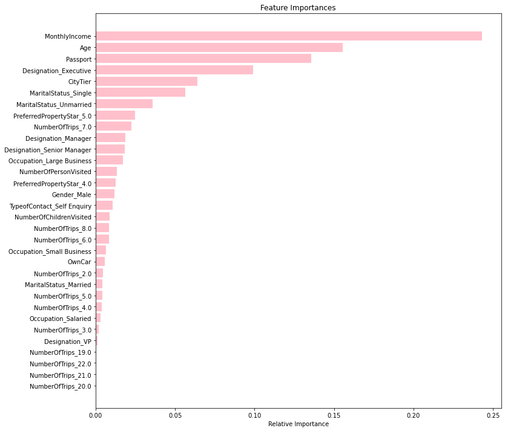

```python
#generate a graph that will show the gini importance of the features for better insights
importances = gbc_tuned.feature_importances_
indices = np.argsort(importances)

plt.figure(figsize=(12,12))
plt.title('Feature Importances')
plt.barh(range(len(indices)), importances[indices], color='pink', align='center')
plt.yticks(range(len(indices)), [feature_names[i] for i in indices])
plt.xlabel('Relative Importance')
plt.show()
```

### Feature Importance of Random Forest

We are also going ti run it through random forest

```python
#gini importance
print (pd.DataFrame(rf.feature_importances_, columns = ["Imp"], index = X_train.columns).sort_values(by = 'Imp', ascending = False))
```

```
                                 Imp
MonthlyIncome               0.173160
Age                         0.156237
Passport                    0.075170
NumberOfChildrenVisited     0.048652
CityTier                    0.044468
NumberOfPersonVisited       0.041316
Designation_Executive       0.033994
Gender_Male                 0.033949
TypeofContact_Self Enquiry  0.031563
MaritalStatus_Single        0.031335
PreferredPropertyStar_5.0   0.030239
OwnCar                      0.029928
PreferredPropertyStar_4.0   0.025351
NumberOfTrips_2.0           0.024615
Occupation_Small Business   0.024021
Occupation_Salaried         0.022971
MaritalStatus_Unmarried     0.021235
MaritalStatus_Married       0.020894
NumberOfTrips_3.0           0.019523
Designation_Manager         0.018025
Occupation_Large Business   0.016038
NumberOfTrips_7.0           0.013913
NumberOfTrips_6.0           0.013441
NumberOfTrips_5.0           0.012728
Designation_Senior Manager  0.012137
NumberOfTrips_4.0           0.012116
NumberOfTrips_8.0           0.008198
Designation_VP              0.004611
NumberOfTrips_19.0          0.000164
NumberOfTrips_22.0          0.000003
NumberOfTrips_21.0          0.000003
NumberOfTrips_20.0          0.000000
```

```python
feature_names = X_train.columns
```

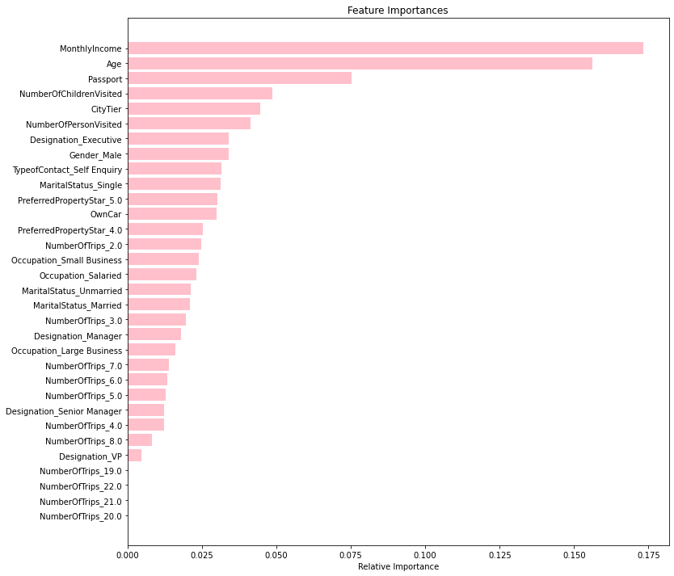

```python
importances = rf.feature_importances_
indices = np.argsort(importances)

plt.figure(figsize=(12,12))
plt.title('Feature Importances')
plt.barh(range(len(indices)), importances[indices], color='pink', align='center')
plt.yticks(range(len(indices)), [feature_names[i] for i in indices])
plt.xlabel('Relative Importance')
plt.show()
```

# Actionable Insights & Recommendations

### Business Recommendations and Insights

Using the model to predict which customers will buy the travel package when offered, here are factors would be given importance:

- The most important factors which could be used to determine if customers that most likely to buy a package are Monthly Income, Age of the customer and if a customer owns a Passport or not and this plays very important role in customer choosing the package.
- For the new package to be picked, all of the above specified feature values should be High.
- The model would recommend the travel packages advertised to customers the age from 40 and below and with a Monthly Income of up to 40,000.
- Also try splitting Customers based on their salary, passport, owning a car.
- Customers in City Tier especially those in tier 3 can also be targeted to advertise the travel package because they also have a high likelihood of also purchasing the travel package.
- Also customers who are in Manager designation has to be target for Marketing.
- Male and also single customers display a greater chance of acquiring the travel package.
- Those customers who prefer 5 star properties can also be targeted to buy travel package.

Factors from customer interaction data which will boost the chances of the customer buying the travel package that needs to be considered are:

- Earning a PitchSatisfactionScore of either 3 or 5
- A higher duration of pitch by salesman to the customer
- The travel company doing numerous or collective followups with a customer. An example would be have the number of 6 followups with a customer can persuade a customer to purchase a travel package.